# NCCS Data Exploration

Matt Peyton

9/25/2019

## About the National Center for Charitable Statistics (NCCS)

### Getting Started with NCCS Data

[Beginners Guide to NCCS Data](https://nccs.urban.org/sites/default/files/2018-12/Guide%20to%20Using%20NCCS%20Data.pdf)

[NCCS Data: R Users Guide](https://nccs.urban.org/publication/nccs-data-r-users-guide#nccs-data-r-users-guide)

**3 Types of Files**

- IRS Business Master Files (BMF)
- NCCS Core Files (Core)
- IRS Statistics of Income Exempt Organizations Sample Files (SOI)

### IRS Business Master Files (BMF)

**Updated**

- BMF datasets are generally released multiple times per year; at least one per year is available going back to 1995
- Files are updated by the IRS on a regular basis, and downloaded to the NCCS Data Archive several times per year
- The information in the BMF is almost always the most up to date information about these organizations and their filing statuses.

**Contains**

- Each file represents the number of organizations registered with the IRS during the month/year indicated
- The BMF contains records both for active and inactive organizations, as well as registered organizations operating below the minimum requirements for filing a Form 990 or 990-EZ.

**Does Not Contain**

- The number of total fields from the Form 990 are very limite
- Financial fields are limited solely to total revenue and total assets
- Many Parts of the Form 990 are not represented at all

### NCCS Core Files

[Data Dictionary](https://nccs-data.urban.org/showDD.php?ds=core)

**Updated**

- Released once per year, the NCCS Core Files represent the entire population of active, reporting organizations of the given type filing within a given circa year

**Contains**

- Thus, each Core File contains multiple fiscal years’ worth of information, but only one record for each EIN.
- This data is aggregated to show an accurate snapshot of actual nonprofit activity within the given year, accounting for the varying filing patterns and fiscal years of different nonprofits.
- The NCCS Core Files contain a far wider selection of financial fields from the Form 990 than the BMF, including detailed information on revenue, expenses, and assets.
- Further, the Core files are subject to the NCCS validation procedure before release, making the data more accurate than that contained in the BMF.

## Get CORE Files

```r
core2015pc <- getcorefile(2015, "pc")
```

```
## No encoding supplied: defaulting to UTF-8.
```

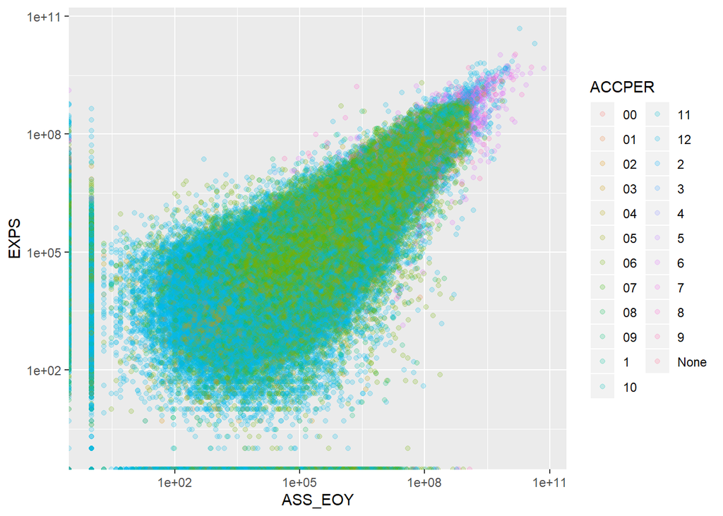

```r
core2015pc %>%
    ggplot(aes(x=ASS_EOY, y=EXPS, color=ACCPER)) +
    geom_point(alpha=.2)+
    scale_x_log10() +
    scale_y_log10()
```

```r
    #scale_x_continuous(labels = comma, limits=c(0,20000000000)) +
    #scale_y_continuous(labels = comma, limits=c(0,20000000000))
```